# Laser Cooling

Author

Daniel Fischer

# Introduction

In general, several mechanisms can exert forces on atoms exposed to laser fields. One example is the *optical dipole force*, a conservative force arising from the Autler–Townes shift (for details see the page on Rabi Oscillations) at positions with a non-vanishing laser-intensity gradient. Another mechanism is the *photon scattering force*, which originates from the impulse an atom receives during each photon-absorption and photon-emission event.

This chapter examines how the scattering force can be used experimentally to cool atomic gases to extremely low temperatures and to confine them within small spatial regions. A concise and very readable overview of these mechanisms can also be found in the article *Laser Cooling and Trapping of Neutral Atoms* by Harold J. Metcalf and Peter van der Straten [@doi:10.1002/9783527600441.oe005](https://doi.org/10.1002/9783527600441.oe005), which closely parallels the material presented here.

After studying this chapter, you will be able to:

- Explain the origin of the scattering force and how it depends on detuning and saturation.
- Derive the velocity-dependent force leading to Doppler cooling.
- Explain the concept of optical molasses and its relation to velocity damping.
- Compute the Doppler cooling limit and understand its physical meaning.
- Describe the principles of magneto-optical trapping and the role of the Zeeman effect.

# 1. Doppler Cooling

Laser cooling relies on the fact that light can exert forces on atoms. Before examining Doppler cooling in detail, we first analyze the *scattering force*, which arises when atoms repeatedly absorb and spontaneously emit photons. This force is central to all radiative cooling mechanisms and forms the foundation of optical molasses, magneto-optical traps, and most modern cold-atom techniques.

## 1.1 The Scattering Force

To understand the scattering force, let us recall that a force is defined as the rate of change of momentum,
$$\vec F = \frac{d\vec p}{dt}.$$

Photons carry momentum. A single photon of wave vector $\vec{k}$ has momentum
$$\vec p_{\text{ph}} = \hbar\vec{k},$$
directed along the laser propagation direction. Therefore, each photon *absorption* event gives the atom a momentum kick of $+\hbar\vec k$. A *spontaneous emission* event also imparts momentum of magnitude $\hbar k$, but in a random direction, so its average contribution to the force is zero.

Stimulated emission does **not** contribute to a net force either, because the emitted photon is identical to the absorbed one and travels in the same direction; an absorption–stimulated-emission cycle therefore results in zero net momentum transfer.

Thus the **net force comes entirely from directed absorption** events, each of which transfers $\hbar\vec k$, occurring at the spontaneous scattering rate.

Using the spontaneous scattering rate from Equation 13 derived from the *Optical Bloch Equations*, the resulting average force is

$$\vec{F}
= (\hbar\vec{k})\Gamma
= \hbar\vec{k}\,\frac{\gamma}{2}\,
\frac{S_0}{1 + S_0 + \frac{4\delta^2}{\gamma^2}}.
\tag{1}$$

This force points along the laser beam direction and is largest when the detuning $\delta$ is zero.

## 1.2 Doppler Cooling

The expression in Equation 1 describes atoms at rest. For a moving atom, however, the laser frequency is Doppler-shifted in the atom’s rest frame. The first-order (non-relativistic) Doppler shift is

$$\Delta\omega_D = -\vec{k}\cdot\vec{v},$$

valid when $v \ll c$. Substituting this shifted frequency into the scattering-force expression gives

$$\vec{F}
= \hbar\vec{k}\frac{\gamma}{2}
\frac{S_0}{1 + S_0 + \frac{4(\delta - \vec{k}\cdot\vec{v})^2}{\gamma^2}}.
\tag{2}$$

This expression is fully three-dimensional.  
To make further progress—and because most laser-cooling setups are arranged along fixed beam axes—we now **restrict the motion to one spatial dimension**, say the $x$-axis. In this 1D geometry:

- the wave vector becomes $\vec{k} = k\,\hat{x}$,
- the velocity becomes $\vec{v} = v\,\hat{x}$,
- and therefore $\vec{k}\cdot\vec{v} = kv$.

This simplifies the Doppler-shifted scattering force and allows us to study how it depends on the sign and magnitude of the atomic velocity.

### Two Counterpropagating Beams

We now consider the standard cooling configuration of **two counterpropagating laser beams**, one with wave vector $+k$ and one with $-k$. Neglecting Autler–Townes shifts and interference effects, the total force along the beam axis is the difference of the forces from the two beams:

$$\begin{aligned}
F
&= \hbar k\frac{\gamma}{2}
\left[
\frac{S_0}{1 + S_0 + \tfrac{4(\delta - kv)^2}{\gamma^2}}
-
\frac{S_0}{1 + S_0 + \tfrac{4(\delta + kv)^2}{\gamma^2}}
\right] \\[6pt]
&\approx
\hbar k S_0 \frac{kv}{2}
\frac{16(\delta/\gamma)}
{ 1 + \frac{8}{\gamma^2}(\delta^2 + k^2 v^2)
+ \frac{16}{\gamma^4}(\delta^2 + k^2 v^2)^2 } ,
\end{aligned}
\tag{3}$$

where the second line assumes the **low-saturation limit** $S_0 \ll 1$.

Figure 1 shows the resulting force as a function of velocity for red detuning ($\delta<0$). Near $v=0$, the force always opposes the motion:

- for $v>0$, the force is negative;
- for $v<0$, the force is positive.

Thus the atom is slowed—this is **Doppler cooling**. Using three orthogonal beam pairs generalizes this to **three-dimensional optical molasses**.

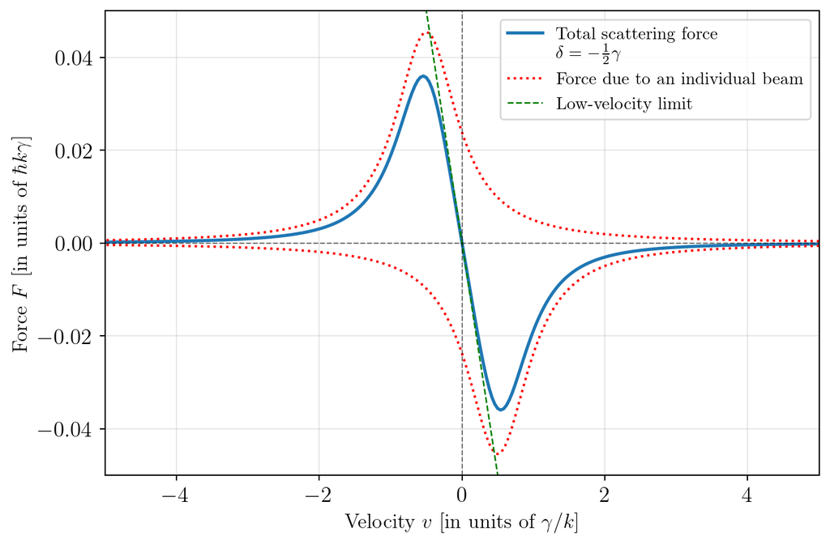

```python
import numpy as np
import matplotlib.pyplot as plt

# --- Set up plot styling ---
plt.rcParams['text.usetex'] = True
plt.rcParams['font.family'] = 'serif'
plt.rcParams['font.size'] = 14


def scattering_force_single_beam(v, k, gamma, delta, S0, hbar=1):
    """
    Scattering force from a single laser beam including Doppler shift.

    Parameters:
    -----------
    v : array-like
        Atomic velocity (in units where recoil velocity = 1)
    k : float
        Wave vector magnitude
    gamma : float
        Natural linewidth
    delta : float
        Laser detuning (negative for red detuning)
    S0 : float
        On-resonance saturation parameter
    hbar : float
        Reduced Planck constant (default=1 for natural units)

    Returns:
    --------
    F : array-like
        Scattering force
    """
    detuning_eff = delta - k * v
    F = hbar * k * (gamma/2) * S0 / (1 + S0 + 4*detuning_eff**2/gamma**2)
    return F


def doppler_cooling_force(v, k, gamma, delta, S0, hbar=1):
    """
    Total force from two counterpropagating beams (Doppler cooling).

    Parameters:
    -----------
    v : array-like
        Atomic velocity
    k : float
        Wave vector magnitude
    gamma : float
        Natural linewidth
    delta : float
        Laser detuning (negative for red detuning)
    S0 : float
        On-resonance saturation parameter
    hbar : float
        Reduced Planck constant (default=1 for natural units)

    Returns:
    --------
    F : array-like
        Total cooling force
    """
    # Force from beam propagating in +x direction (opposes +v)
    F_plus = scattering_force_single_beam(v, k, gamma, delta, S0, hbar)

    # Force from beam propagating in -x direction (opposes -v)
    F_minus = scattering_force_single_beam(-v, k, gamma, delta, S0, hbar)

    # Total force (note the sign: +k beam gives +F, -k beam gives -F)
    F_total = F_plus - F_minus

    return F_total


def doppler_cooling_force_low_sat(v, k, gamma, delta, S0, hbar=1):
    """
    Doppler cooling force in low saturation approximation (S0 << 1).
    This is the analytical approximation from Eq. (eq-coolingforce).
    """
    numerator = hbar * k * S0 * (k * v / 2) * 16 * (delta / gamma)
    denominator = (1 + 8/gamma**2 * (delta**2 + k**2 * v**2) +
                   16/gamma**4 * (delta**2 + k**2 * v**2)**2)
    return numerator / denominator

def linear_approx(v, k, gamma, delta, S0, hbar=1):
    F = 8 * v * hbar/gamma * (k**2) * S0 * delta / (1 + (2*delta/gamma)**2)**2
    return F


# Set parameters (in natural units where gamma = 1)
gamma = 1.0
k = 1.0  # Wave vector
delta_values = [-0.5]  # Red detuning (negative values)
S0 = 0.1  # Low saturation

# Velocity range (in units of recoil velocity)
v = np.linspace(-10, 10, 500)

# Create figure with subplots
fig, ax = plt.subplots(figsize=(7.5, 5))

# Plot 1: Force vs velocity for different detunings
for delta in delta_values:
    F = doppler_cooling_force(v, k, gamma, delta, S0)
    Fl = scattering_force_single_beam(v, k, gamma, delta, S0)
    Fr = scattering_force_single_beam(v, -k, gamma, delta, S0)
    Flin = linear_approx(v, k, gamma, delta, S0)
    ax.plot(v, F, linewidth=2, label=r'\noindent Total scattering force \\$\delta = -\frac{1}{2}\gamma$')
    ax.plot(v, Fl, 'r:', linewidth=1.5, label=r'Force due to an individual beam')
    ax.plot(v, Fr, 'r:', linewidth=1.5)
    ax.plot(v, Flin, 'g--', linewidth=1, label=r'Low-velocity limit')

ax.axhline(y=0, color='k', linestyle='--', linewidth=0.8, alpha=0.5)
ax.axvline(x=0, color='k', linestyle='--', linewidth=0.8, alpha=0.5)
ax.set_xlabel('Velocity $v$ [in units of $\gamma/k$]', fontsize=13)
ax.set_ylabel('Force $F$ [in units of $\hbar k \gamma$]', fontsize=13)
ax.legend(fontsize=11)
ax.grid(True, alpha=0.3)
ax.set_xlim(-5, 5)
ax.set_ylim(-.05, .05)


plt.tight_layout()
plt.show()
```

## 1.3 Low-velocity limit

For $kv \ll \gamma$ and $kv \ll |\delta|$, Equation 3 reduces to a linear viscous force,

$$F = -\alpha v,
\qquad
\alpha = -\frac{8\,\hbar k^2 S_0(\delta/\gamma)}{\bigl[1+(2\delta/\gamma)^2\bigr]^2},$$

which shows that, at sufficiently small velocity, the Doppler cooling force behaves like friction.

**NoteDerivation**

We start from the low-saturation approximate expression from Equation 3 (one-dimensional motion along the beam axis):

$$F \approx \hbar k S_0 \frac{k v}{2}\; \frac{16(\delta/\gamma)}
{ 1 + \frac{8}{\gamma^2}(\delta^2 + k^2 v^2)
+ \frac{16}{\gamma^4}(\delta^2 + k^2 v^2)^2 } .$$

Now take the **low-velocity limit** $k v \ll \gamma$ and $k v \ll |\delta|$. In this limit we can set $k^2 v^2 \to 0$ in the denominator, so the denominator reduces to

$$1 + \frac{8\delta^2}{\gamma^2} + \frac{16\delta^4}{\gamma^4}
= \bigl[\,1 + (2\delta/\gamma)^2 \,\bigr]^2.$$

The numerator simplifies as

$$\hbar k S_0\cdot\frac{k v}{2}\cdot 16\frac{\delta}{\gamma}
= 8\,\hbar k^2 S_0\frac{\delta}{\gamma}\, v .$$

Combining numerator and denominator gives

$$F \approx \frac{8\,\hbar k^2 S_0(\delta/\gamma)}{\bigl[1+(2\delta/\gamma)^2\bigr]^2}\; v .$$

Writing this in the standard damping form $F=-\alpha v$ gives

$$\alpha = -\frac{8\,\hbar k^2 S_0(\delta/\gamma)}{\bigl[1+(2\delta/\gamma)^2\bigr]^2}.$$

Since the factors $\hbar$, $k^2$, $S_0$, and $\gamma$ are positive, the sign of $\alpha$ depends entirely on the detuning $\delta$:

- For **red detuning** $\delta<0$ we have $\alpha>0$, so $F=-\alpha v$ is **damping** (opposes the velocity) and yields cooling.
- For **blue detuning** $\delta>0$ we get $\alpha<0$, so $F$ amplifies the motion (heating).

Thus Doppler cooling only occurs for red detuning.

### Cooling (energy) rate and time constant

With kinetic energy $E=\tfrac12 m v^2$ we have

$$\left(\frac{dE}{dt}\right)_{\text{cool}} = F v = -\alpha v^2 = -\frac{2\alpha}{m}\,E.
\tag{4}$$

Hence the energy decays exponentially,

$$E(t) = E(0)\,e^{- (2\alpha/m)\,t},$$

with an energy damping rate $2\alpha/m$ and a characteristic cooling time

$$\tau_{\rm cool} = \frac{m}{2\alpha}.$$

For red detuning ($\alpha>0$), $\tau_{\rm cool}$ is positive and sets how quickly the atomic energy decreases.

### Optimal detuning for maximum damping

To maximize the damping strength $|\alpha|$, set $x = \delta/\gamma$ and maximize

$$|\alpha| \propto \frac{|x|}{\bigl[1+(2x)^2\bigr]^2}.$$

The maximum occurs at

$$|x| = \frac{1}{2\sqrt{3}} \approx 0.289, \qquad \delta \approx -\frac{\gamma}{2\sqrt{3}}.$$

This detuning gives the fastest damping, but not the lowest achievable steady-state temperature. The minimal Doppler temperature,

$$T_{\min}=\frac{\hbar \gamma}{2k_B},$$

is reached at $\delta = -\gamma/2$. Both optimal detunings are of order $\gamma$, but correspond to different goals (fast cooling vs. lowest temperature).

## 1.4 The Doppler Cooling Limit

Each spontaneous emission event imparts a random recoil momentum of magnitude $\hbar k$ to the atom.  
These kicks act like a momentum-space diffusion process. Averaging over many such events gives a *heating rate*.

To estimate it, note first that the mean kinetic energy of a particle in one dimension is related to temperature via the Maxwell–Boltzmann distribution,
$$E = \frac{1}{2} m\langle v^2\rangle = \frac{1}{2} k_B T .$$

The heating rate is the **mean recoil energy** per scattering event multiplied by the scattering rate:
$$\left(\frac{dE}{dt}\right)_{\text{heat}}
\approx
\frac{\hbar^2 k^2}{m}\,\Gamma.$$

**NoteDerivation of the mean recoil energy**

The kinetic energy of an atom with momentum $\vec p$ is
$$E = \frac{p^2}{2m}.$$
During a scattering event the atom receives a momentum kick $\Delta \vec p$ of magnitude $\hbar \vec k$. Its new momentum is
$$\vec p'=\vec p + \Delta \vec p$$
so the new kinetic energy is
$$E = \frac{(\vec p+\Delta \vec p)^2}{2m}.$$
The change in kinetic energy is
$$\Delta E = E' - E = \frac{(\vec p+\Delta \vec p)^2-p^2}{2m} = \frac{2\vec p\Delta \vec p + (\Delta p)^2}{2m}$$

This expression has two contributions:

1. **The cross term:**
   $$\frac{\vec p\Delta \vec p}{m}.$$
   Because spontaneous emission is isotropic, the direction of the recoil is random, so
   $$\langle \Delta \vec p\rangle =0 , \quad \Rightarrow \quad \langle \vec p \Delta \vec p\rangle = 0.$$
   This term averages to zero.
2. **Diffusion term:**
   $$\frac{(\Delta p)^2}{2m}.$$
   This is always positive and therefore always increases the kinetic energy.

Thus the mean energy increase per recoil event is
$$\langle \Delta E\rangle = \frac{\langle (\Delta p)^2 \rangle }{2m}.$$
For a photon of wave number $k$ the recoil momentum has magnitude $|\Delta p|=\hbar k$, and emission directions are random. Therefore,
$$\langle \Delta E\rangle = \frac{(\hbar k)^2}{2m}$$
is the mean recoil energy per spontaneous emission event.

Using the low-velocity form of the scattering rate,
$$\Gamma = \frac{\gamma}{2}\,
\frac{S_0}{1 + (2\delta/\gamma)^2},$$
we obtain the approximate heating rate
$$\left(\frac{dE}{dt}\right)_{\text{heat}}
\approx
\frac{\hbar^2 k^2}{m}\,
\frac{\gamma S_0}{1 + (2\delta/\gamma)^2}.
\tag{5}$$

This expression implicitly assumes that the atomic velocity distribution is broad enough that recoil events effectively randomize momentum, but not so large that Doppler shifts modify $\Gamma$ appreciably.

### Steady-state temperature

Cooling (from Equation 4) and heating (from Equation 5) balance in steady state:

$$\left(\frac{dE}{dt}\right)_{\text{cool}}
+
\left(\frac{dE}{dt}\right)_{\text{heat}}
= 0.$$

This is minimized for the optimal detuning $\delta = -\gamma/2$, yielding the **Doppler cooling limit**:
$$T_{\min}
= \frac{m}{k_B}\langle v^2\rangle_{\min}
= \frac{\hbar\gamma}{2k_B}.$$

This is the fundamental temperature limit for Doppler cooling based solely on absorption and spontaneous emission.

**NoteBeyond the Doppler limit**

Colder temperatures can be achieved through mechanisms requiring multilevel structure and polarization gradients, such as *Sisyphus* or *polarization-gradient cooling*. These are known as **sub-Doppler processes** and can reach temperatures near the recoil limit:

$$T_{\text{recoil}}
= \frac{\hbar k^2}{2 m k_B}.$$

# 2. Magneto-Optical Traps (MOTs)

Laser cooling, as discussed in the previous section, can reduce the velocity spread of an atomic gas. However, *optical molasses alone does not confine atoms spatially*: the ensemble slowly drifts away. This limitation is a consequence of the **Optical Earnshaw Theorem**, which states that *no purely optical scattering-force configuration can create a stable 3D trap for structureless atoms*.

## 2.1 Optical Earnshaw Theorem

The central assumption is that atoms are **point-like dipoles** with internal structure *independent* of position. Under this assumption, the scattering force from a laser field is proportional to the **Poynting vector**
$$\vec S = \frac{1}{\mu_0}\,\vec E \times \vec B.$$

From Poynting’s theorem, the divergence of $\vec S$ is
$$\nabla\!\cdot\vec S
= -\, \vec J\cdot\vec E
- \frac{1}{2}\frac{d}{dt}\!\left(\varepsilon_0 E^2 + \frac{1}{\mu_0}B^2\right).$$

In the region where atoms are located:

- there are **no free charges or currents**, so $\vec J = 0$,
- the laser field is (after averaging) time-independent.

Thus,
$$\nabla\!\cdot\vec S = 0.$$

If the force is proportional to $\vec S$, then
$$\nabla\!\cdot\vec F = 0.$$

A divergence-free vector field **cannot point inward on the entire boundary of any finite volume**. Therefore:

> **No configuration of scattering forces alone can create a stable trapping potential.**  
> Any such trap must “leak”—atoms eventually escape.

This motivates adding a mechanism that **breaks the assumptions** of the Earnshaw theorem. In a magneto-optical trap, this loophole is provided by making the *atomic energy levels position dependent* using a magnetic field.

## 2.2 Position-dependent structure: Zeeman effect

A MOT introduces a weak, spatially varying magnetic field produced by **anti-Helmholtz coils**, creating a near-linear field gradient,
$$B_z(z) \approx B'_z\,z.$$

This magnetic field shifts the energies of magnetic sublevels via the **Zeeman effect**. For a simple model, consider:

- a ground state with orbital angular momentum $\ell=0$ (an **s-state**),
- an excited state with $\ell=1$ (a **p-state**) with magnetic sublevels $m_\ell=-1,0,+1$.

Ignoring spin for now, the magnetic sublevels of the excited state shift by
$$\Delta\omega_{\rm Zeeman}
= \frac{\mu_B}{\hbar}\,g\,m_\ell\,B_z,$$
where $\mu_B$ is the Bohr magneton and $g$ is the Landé g-factor.

Thus, at positive $z$ the $m_\ell=+1$ state shifts up in energy, while the $m_\ell=-1$ state shifts down; the opposite happens at negative $z$. The key consequence: **resonance frequencies now depend on position**.

This breaks the assumptions of the optical Earnshaw theorem and allows a restoring force.

## 2.3 Selection rules and polarization

A second ingredient is the ability to **drive transitions selectively** into specific Zeeman sublevels using circular polarization:

- A beam propagating in the **$+z$ direction** with **$\sigma^+$** polarization drives
  $$\Delta m_\ell = +1 \quad \Rightarrow\quad m_\ell = +1 \text{ excited state}.$$
- A counterpropagating beam from **$−z$** with **$\sigma^-$** polarization drives
  $$\Delta m_\ell = -1 \quad \Rightarrow\quad m_\ell = -1 \text{ excited state}.$$

Including a slight **red detuning** makes the Doppler cooling mechanism work simultaneously: atoms feel both **a restoring force** *and* **a velocity-damping force**.

The combination of:

1. Doppler cooling
2. Zeeman-shift–induced spatial dependence
3. Polarization-selective transitions

creates a **three-dimensional viscous and restoring force field**: the magneto-optical trap.

To visualize how the MOT combines a spatially varying magnetic field with polarization-dependent optical forces, Figure 2 shows (left) the magnetic quadrupole field generated by anti-Helmholtz coils and (right) the resulting Zeeman-shifted excited-state manifold together with the $\sigma^\pm$ laser couplings.

The linear field gradient, evident in the left panel, provides the position-dependent Zeeman shift that breaks the assumptions of the optical Earnshaw theorem. The right panel illustrates how each circularly polarized beam selectively addresses one of the shifted $m_\ell=\pm1$ states, thereby producing a restoring force toward the trap center.

```python
import numpy as np
import matplotlib.pyplot as plt
from scipy.special import ellipk, ellipe


# --- Set up plot styling ---
plt.rcParams['text.usetex'] = True
plt.rcParams['font.family'] = 'serif'
plt.rcParams['font.size'] = 14

# Constants
mu0 = 4 * np.pi * 1e-7

# --- FIELD CALCULATION FUNCTIONS (re-used for context) ---
def B_field_single_loop(x_point, z_point, R, current, z_offset):
    # Vectorized Biot-Savart function
    rho = np.abs(x_point)
    z_prime = z_point - z_offset

    k_squared_numerator = 4 * R * rho
    k_squared_denominator = (R + rho)**2 + z_prime**2

    k_squared = np.divide(k_squared_numerator, k_squared_denominator,
                          out=np.zeros_like(x_point),
                          where=k_squared_denominator != 0)

    k_squared = np.where(k_squared < 0, 0, k_squared)
    k_squared = np.where(k_squared > 1, 1.0 - 1e-9, k_squared)

    K_val = ellipk(k_squared)
    E_val = ellipe(k_squared)

    term1 = (mu0 * current) / (2 * np.pi)
    denom_sqrt_K = np.sqrt(k_squared_denominator)

    # Bx Component
    m1 = (rho != 0)
    Bx_numerator = z_prime * (E_val * ( (R**2 + rho**2 + z_prime**2) / ((R - rho)**2 + z_prime**2) ) - K_val)
    Bx_factor = term1 / denom_sqrt_K

    Bx = np.zeros_like(x_point)
    Bx[m1] = Bx_factor[m1] * (Bx_numerator[m1] / rho[m1])
    Bx *= np.sign(x_point)

    # Bz Component
    Bz_factor = term1 / denom_sqrt_K
    Bz_term = K_val + E_val * ( (R**2 - rho**2 - z_prime**2) / ((R - rho)**2 + z_prime**2) )
    Bz = Bz_factor * Bz_term

    return Bx, Bz

def B_anti_helmholtz_2D(x, z, R_coil, d_coil, current):
    Bx1, Bz1 = B_field_single_loop(x, z, R_coil, current, -d_coil/2)
    Bx2, Bz2 = B_field_single_loop(x, z, R_coil, -current, d_coil/2)
    return Bx1 + Bx2, Bz1 + Bz2


# --- Plotting Setup ---
fig, (ax1, ax2) = plt.subplots(1, 2, figsize=(8, 3), width_ratios=[2,3])

# Coil parameters
R_coil = 1.0
d_coil = R_coil
current = 1.0

# Plotting area
xlim = (-2.5 * R_coil, 2.5 * R_coil)
zlim = (-2.5 * R_coil, 2.5 * R_coil)
ax1.set_xlim(xlim)
ax1.set_ylim(zlim)
ax1.set_aspect('equal')

# Create a grid for streamplot
num_points = 100
x_grid = np.linspace(xlim[0], xlim[1], num_points)
z_grid = np.linspace(zlim[0], zlim[1], num_points)
X, Z = np.meshgrid(x_grid, z_grid)

# Calculate the magnetic field at each grid point
Bx_field, Bz_field = B_anti_helmholtz_2D(X, Z, R_coil, d_coil, current)

# --- Define Explicit Symmetric Seed Points (Avoiding Axes) ---

# 1. Define seeds only for the first quadrant (x > 0, z > 0)
num_radial_points = 5
num_angular_points = 6

# Radial distances: Start well away from the origin (0.4)
radial_distances = np.linspace(0.4, 2.0, num_radial_points)

# Angular range: from 15 degrees (pi/12) to 75 degrees (5*pi/12), avoiding the axes (0 and 90)
angles = np.linspace(np.pi / 12, 5 * np.pi / 12, num_angular_points)

# Generate seed points in Quadrant 1
seed_x_q1 = []
seed_z_q1 = []

for r in radial_distances:
    for angle in angles:
        seed_x_q1.append(r * np.cos(angle))
        seed_z_q1.append(r * np.sin(angle))

seed_x_q1 = np.array(seed_x_q1)
seed_z_q1 = np.array(seed_z_q1)

# 2. Reflect Q1 seeds to the other three quadrants to ensure symmetry

# Quadrant 2 (x < 0, z > 0) -> Reflection across z-axis (x -> -x)
seed_x_q2 = -seed_x_q1
seed_z_q2 = seed_z_q1

# Quadrant 3 (x < 0, z < 0) -> Reflection across origin (x -> -x, z -> -z)
seed_x_q3 = -seed_x_q1
seed_z_q3 = -seed_z_q1

# Quadrant 4 (x > 0, z < 0) -> Reflection across x-axis (z -> -z)
seed_x_q4 = seed_x_q1
seed_z_q4 = -seed_z_q1

# 3. Combine all seeds
seed_x_all = np.concatenate([seed_x_q1, seed_x_q2, seed_x_q3, seed_x_q4])
seed_z_all = np.concatenate([seed_z_q1, seed_z_q2, seed_z_q3, seed_z_q4])

seed_points = np.vstack([seed_x_all, seed_z_all])

# --- Streamline Visualization with Fixed Symmetric Seed Points ---
ax1.streamplot(X, Z, Bx_field, Bz_field,
              color='black',
              linewidth=1,
              start_points=seed_points.T,
              arrowstyle='->',
              arrowsize=1.5)

# --- Plot Coil Cross-sections ---
circle_radius = 0.1

# Coil 1 (z = -d_coil/2)
ax1.add_patch(plt.Circle((R_coil, -d_coil/2), circle_radius,color='lightgray', zorder=5))
ax1.text(R_coil+0.025, -d_coil/2+0.021, r'$\times$', color='black', fontsize=8, ha='center', va='center', weight='bold', zorder=6)
ax1.add_patch(plt.Circle((-R_coil, -d_coil/2), circle_radius, color='lightgray', zorder=5))
ax1.text(-R_coil+0.025, -d_coil/2+0.045, r'$\cdot$', color='black', fontsize=12, ha='center', va='center', weight='bold', zorder=6)

# Coil 2 (z = d_coil/2)
ax1.add_patch(plt.Circle((R_coil, d_coil/2), circle_radius, color='lightgray', zorder=5))
ax1.text(R_coil+0.025, d_coil/2+0.045, r'$\cdot$', color='black', fontsize=12, ha='center', va='center', weight='bold', zorder=6)
ax1.add_patch(plt.Circle((-R_coil, d_coil/2), circle_radius, color='lightgray', zorder=5))
ax1.text(-R_coil+0.025, d_coil/2+0.021, r'$\times$', color='black', fontsize=8, ha='center', va='center', weight='bold', zorder=6)

ax1.spines['top'].set_visible(False)
ax1.spines['right'].set_visible(False)
ax1.spines['bottom'].set_visible(False)
ax1.spines['left'].set_visible(False)
ax1.set_xticks([])
ax1.set_yticks([])
ax1.grid(False)


# --- Parameters for the Atomic System and MOT ---
# Unperturbed transition frequency (arbitrary units for plotting, but represents E/hbar)
omega0_level = 1.0 # Energy of the unperturbed excited state (l=1, ml=0)

# Zeeman splitting coefficient (related to Bohr magneton and g-factor)
# This determines the slope of the Zeeman-split levels.
mu_B_prime_g = 0.2 # (mu_B * g_factor * B_gradient_strength) in E/hbar units

# Laser detuning
delta0 = 0.2 # Amount of red-detuning (omega0 - omega)
laser_omega_level = omega0_level - delta0

# --- Plotting Range ---
z_min, z_max = -2.0, 2.0
z_axis = np.linspace(z_min, z_max, 200)

# --- Zeeman Level Calculations ---
# l=0 ground state (ml=0)
E_ground = 0.0 * z_axis

# l=1 excited states
# In an anti-Helmholtz field, B(z) is roughly B'z. So Zeeman splitting is proportional to z.
# Assuming B(z) = B' * z (linear field with gradient B' at origin)
# Energy split: E_ml = E_0 + ml * (mu_B * g) * B(z)
# For simplicity, let mu_B_prime_g * z represent the ml=1 splitting from ml=0 level
# The sign depends on the convention and actual field direction.
# For the plot, ml=+1 increases with z, ml=-1 decreases with z.
E_l1_ml_1 = omega0_level + mu_B_prime_g * z_axis  # m_l = +1
E_l1_ml_0 = omega0_level * np.ones_like(z_axis)    # m_l = 0
E_l1_ml_neg1 = omega0_level - mu_B_prime_g * z_axis # m_l = -1
```

```python
# --- Plot Energy Levels ---
ax2.plot(z_axis, E_ground, 'k-', linewidth=1.5, label=r'$l=0, m_l=0$')
ax2.plot(z_axis, E_l1_ml_0, 'k-', linewidth=1.5, label=r'$l=1, m_l=0$')
ax2.plot(z_axis, E_l1_ml_1, 'k-', linewidth=1.5, label=r'$l=1, m_l=+1$')
ax2.plot(z_axis, E_l1_ml_neg1, 'k-', linewidth=1.5, label=r'$l=1, m_l=-1$')

ax2.quiver(z_min, -0.2, 4.5, 0, scale=1, scale_units='xy', angles='xy', width=0.003, headwidth=10, headlength=10, headaxislength=9)

# --- Add the fake break here ---
# Coordinates for the rectangle to hide the middle section
break_y_min = 0.5
break_y_max = 0.55
ax2.quiver(0, break_y_max, 0, 2-break_y_max, scale=1, scale_units='xy', angles='xy', width=0.003, headwidth=10, headlength=10, headaxislength=9)
ax2.quiver(0, -0.25, 0, break_y_min+0.22, scale=1, scale_units='xy', angles='xy', width=0.003, headwidth=0, headlength=0, headaxislength=0)
# Add the break symbol "//"
ax2.text(0, (break_y_min + break_y_max) / 2-0.02, r'$//$',
        ha='center', va='center', fontsize=10, color='black', rotation=90)


# --- Plot Laser Frequency (Red-Detuned) ---
ax2.plot([-2,2],[laser_omega_level,laser_omega_level], color='red', linestyle='--', linewidth=1)

# --- Add Transition Arrows and Labels ---
# Arrow for omega0 (unperturbed transition at z=0)
ax2.annotate("", xy=(0.6, omega0_level), xytext=(0.6, E_ground[0]),
            arrowprops=dict(arrowstyle="<->", color="black", lw=1))
ax2.text(0.7, (omega0_level + E_ground[0])/2, r'$\hbar\omega_0$', va='center', ha='left', fontsize=12)
# Arrow for omegaL
ax2.annotate("", xy=(z_min+1, laser_omega_level), xytext=(z_min+1, E_ground[0]),
            arrowprops=dict(arrowstyle="<->", color="black", lw=1))
ax2.text(z_min+1.1, (laser_omega_level + E_ground[0])/2, r'$\hbar\omega_L$', va='center', ha='left', fontsize=12)


# --- Add Labels for Energy Levels and m_l states ---
# Ground state label
ax2.text(z_max + 0.6, -0.25, r'$z, B_z$', va='center', ha='left', fontsize=12)
ax2.text(0.1, 2.05, r'$E$', va='center', ha='left', fontsize=12)


ax2.text(z_max + 0.1, E_l1_ml_1[-1]+0.3, r'$m_\ell$', va='center', ha='left', fontsize=12)
ax2.text(z_max + 0.1, E_ground[0], r'$0$', va='center', ha='left', fontsize=12)
ax2.text(z_max + 0.1, E_l1_ml_0[-1], r'$0$', va='center', ha='left', fontsize=12)
ax2.text(z_max + 0.1, E_l1_ml_1[-1], r'$1$', va='center', ha='left', fontsize=12)
ax2.text(z_max + 0.1, E_l1_ml_neg1[-1], r'$-1$', va='center', ha='left', fontsize=12)
ax2.text(z_min - 0.3, E_ground[0]+0.125, r'$|g\rangle$', va='center', ha='center', fontsize=12)
ax2.text(z_min - 0.3, E_l1_ml_0[-1]+0.125, r'$|e\rangle$', va='center', ha='center', fontsize=12)
ax2.text(z_min - 0.3, E_ground[0]-0.125, r'$\ell=0$', va='center', ha='center', fontsize=12)
ax2.text(z_min - 0.3, E_l1_ml_0[-1]-0.125, r'$\ell=1$', va='center', ha='center', fontsize=12)

# Photon arrows
# --- Parameters for the Sine Wave Arrow ---
start_x = z_min
end_x = z_min+0.6
mid_y = 0.35  # Central y-position for the wave
amplitude = 0.05 # Height of the wave
frequency = 10   # Number of oscillations along the arrow's length
num_points = 100 # Number of points to define the wave (smoother is better)

# 1. Generate the sine wave path
x_path = np.linspace(start_x, end_x, num_points)
y_path = mid_y + amplitude * np.sin(frequency * np.pi * (x_path - start_x) / (end_x - start_x))
y_path[-20:] = y_path[-21]


# 2. Plot the sine wave line
ax2.plot(x_path, y_path, color='red', linewidth=1)
# 3. Add an arrowhead at the end of the sine wave
# We need the last point and a point just before it to calculate the tangent for the arrow direction.
arrow_end_x = x_path[-1]
arrow_end_y = y_path[-1]

# Get a point slightly before the end for tangent calculation
# Using the second to last point
arrow_base_x = x_path[-2]
arrow_base_y = y_path[-2]

# Calculate the direction vector for the arrowhead
dx = arrow_end_x - arrow_base_x
dy = arrow_end_y - arrow_base_y

# Use ax.annotate for the arrowhead, with xytext very close to xy
# The arrow will point from xytext to xy
ax2.annotate("",
            xy=(arrow_end_x, arrow_end_y),
            xytext=(arrow_end_x - dx*0.1, arrow_end_y - dy*0.1), # A short segment just before the end
            arrowprops=dict(arrowstyle="simple, head_length=0.2, head_width=0.15",  # <-- INCREASE THESE VALUES
                            color="red",
                            lw=2,
                            shrinkA=0,
                            shrinkB=0))

ax2.text((start_x+end_x)/2+0.3, mid_y+0.05, r'$\sigma^+$', color='red', va='bottom', ha='center', fontsize=12)


# Photon arrows2
# --- Parameters for the Sine Wave Arrow ---
start2_x = z_max
end2_x = z_max-0.6

# 1. Generate the sine wave path
x2_path = np.linspace(start2_x, end2_x, num_points)
y2_path = mid_y + amplitude * np.sin(frequency * np.pi * (x_path - start_x) / (end_x - start_x))
y2_path[-20:] = y_path[-21]


# 2. Plot the sine wave line
ax2.plot(x2_path, y2_path, color='red', linewidth=1)
# 3. Add an arrowhead at the end of the sine wave
# We need the last point and a point just before it to calculate the tangent for the arrow direction.
arrow2_end_x = x2_path[-1]
arrow2_end_y = y2_path[-1]

# Get a point slightly before the end for tangent calculation
# Using the second to last point
arrow2_base_x = x2_path[-2]
arrow2_base_y = y2_path[-2]

# Calculate the direction vector for the arrowhead
dx2 = arrow2_end_x - arrow2_base_x
dy2 = arrow2_end_y - arrow2_base_y

# Use ax.annotate for the arrowhead, with xytext very close to xy
# The arrow will point from xytext to xy
ax2.annotate("",
            xy=(arrow2_end_x, arrow2_end_y),
            xytext=(arrow2_end_x - dx2*0.1, arrow2_end_y - dy2*0.1), # A short segment just before the end
            arrowprops=dict(arrowstyle="simple, head_length=0.2, head_width=0.15",  # <-- INCREASE THESE VALUES
                            color="red",
                            lw=2,
                            shrinkA=0,
                            shrinkB=0))
ax2.text((start2_x+end2_x)/2-0.2, mid_y+0.05, r'$\sigma^-$', color='red', va='bottom', ha='center', fontsize=12)
```

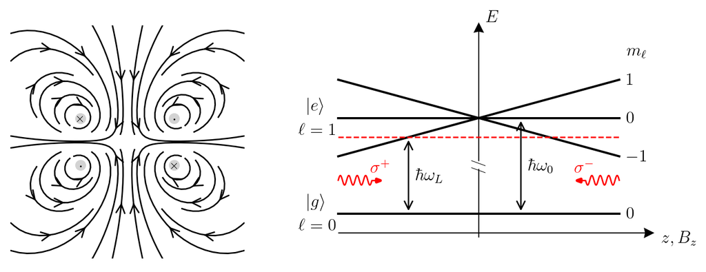

Figure 2: Magnetic field of anti-Helmholtz coils (left) and schematic working principle of the MOT (right). The field gradient produces a position-dependent Zeeman shift, while the $\sigma^\pm$ beams selectively drive the shifted magnetic sublevels to yield a restoring force.

```python
# General settings
ax2.set_xlim([-2.5,2.5])
ax2.set_ylim([-0.5,omega0_level+1])
ax2.spines['top'].set_visible(False)
ax2.spines['right'].set_visible(False)
ax2.spines['bottom'].set_visible(False)
ax2.spines['left'].set_visible(False)
ax2.set_xticks([])
ax2.set_yticks([])


plt.show()
```

# Key Takeaways

- **Optical molasses provides efficient velocity damping** through Doppler cooling, but **cannot confine atoms spatially**. The fundamental limitation arises because, for structureless atoms in static optical fields, the **scattering force field is divergence-free**, prohibiting a true optical trap.
- This constraint is formalized in the **Optical Earnshaw Theorem**, which follows from Poynting’s theorem: with no free charges or currents, the divergence of the Poynting vector vanishes, and thus **no purely optical, inward-pointing force field can enclose a stable trapping volume**.
- **Magneto-optical traps (MOTs) circumvent Earnshaw’s theorem** by giving the atom’s internal structure a **position dependence**—specifically through a spatially varying Zeeman shift in an inhomogeneous magnetic field.
- The **anti-Helmholtz coil configuration** generates a magnetic quadrupole field with a linear gradient. This gradient produces a **position-dependent resonance condition**, which modifies the scattering force asymmetrically for atoms displaced from the trap center.
- **Circular polarization is essential:** a $\sigma^+$ beam selectively drives transitions to the $m_\ell = +1$ Zeeman sublevel, while a counterpropagating $\sigma^-$ beam drives $m_\ell = -1$. Combined with a red detuning, this ensures that **atoms experience a restoring force toward the field zero**, yielding both cooling and trapping.
- The MOT therefore combines:
  1. **Doppler cooling (velocity damping)**
  2. **Zeeman-shift–assisted spatial confinement (restoring force)**  
     into one of the most robust and widely used methods for preparing cold atomic samples.